# Time Series Forecasting (based on Kaggle Competition: Web Traffic Forecasting)

Kaggle Competition https://www.kaggle.com/c/web-traffic-time-series-forecasting

Using Kaggel competition as:

- source of data in related field
- learn from approaches by others (kernels, etc)

## Data

Data sets are available here for download:  
https://www.kaggle.com/c/web-traffic-time-series-forecasting/data

- initial data downloaded from Kaggle and saved in ‘data-input’ folder:
  - train_1.csv (265MB)
  - key_1.csv (711MB)
- due to size of dataset, not uploaded to git repository
- work with sample instead of full data set

### Data Structure (and Size)

Information based on full dataset for reference.

**train:**

- 145K rows x 551 vars
- each row has info for one article based on:
  - article title from URL
  - locale of wikipedia (en.wikipedia.org, zh.wikipedia.org, etc)
  - access type (all-access, desktop, etc)
  - agent (all-agents, spider, etc)
- cols are dates in format X2015.08.02

**key:**

- 8.7M rows x 2 vars
- this file has article info with date appended and a corresponding id number
- i believe only used for uploading data to Kaggle

#### Sampling

Due to the size of data, need to take a sample and work with that.

Sample can be based on:

- random selection of rows (not so useful in this case)
- selected pages
  - topic?
  - key words?
- incorporate dimensions:
  - locale (en.wikipedia)
  - type of access (device?): eg. ‘desktop’
  - ‘agent’ (source?): eg. ‘spider’

First crack:

- filter full train_1.csv for “en.wikipedia” and save
- reduces down to 24k rows
- still 50MB

### WRANGLE SUBJECT DATA

Structure (extended for more date columns):

```
## 'data.frame':    12 obs. of  3 variables:
##  $ Page       : chr  "Howard_Hughes_en.wikipedia.org_desktop_all-agents" "Main_Page_en.wikipedia.org_desktop_all-agents" "Orange_Is_the_New_Black_en.wikipedia.org_desktop_all-agents" "Howard_Hughes_en.wikipedia.org_all-access_spider" ...
##  $ X2015.07.01: int  75357 11952559 28486 137 17207 168 109821 20381245 65947 34167 ...
##  $ X2015.07.02: int  5396 12344021 26685 113 14756 132 13122 20752194 60189 7528 ...
```

Pages:

```
##  [1] "Howard_Hughes_en.wikipedia.org_all-access_all-agents"
##  [2] "Howard_Hughes_en.wikipedia.org_all-access_spider"
##  [3] "Howard_Hughes_en.wikipedia.org_desktop_all-agents"
##  [4] "Howard_Hughes_en.wikipedia.org_mobile-web_all-agents"
##  [5] "Main_Page_en.wikipedia.org_all-access_all-agents"
##  [6] "Main_Page_en.wikipedia.org_all-access_spider"
##  [7] "Main_Page_en.wikipedia.org_desktop_all-agents"
##  [8] "Main_Page_en.wikipedia.org_mobile-web_all-agents"
##  [9] "Orange_Is_the_New_Black_en.wikipedia.org_all-access_all-agents"
## [10] "Orange_Is_the_New_Black_en.wikipedia.org_all-access_spider"
## [11] "Orange_Is_the_New_Black_en.wikipedia.org_desktop_all-agents"
## [12] "Orange_Is_the_New_Black_en.wikipedia.org_mobile-web_all-agents"
```

3 components to Page:

1. Subject
2. Access: ‘all-access’, ‘desktop’, ‘mobile’
3. Agent: ‘all-agents’, ‘spider’

Note that ‘all-access-all-agents’ is the total of the other variations.

### Time Series Data Example

Try with one page variation.

```r
main.all.all <- subject %>% filter(Page=="Main_Page_en.wikipedia.org_all-access_all-agents")
main.all.all.ts <- main.all.all %>% gather(key=date, value=views, -Page)
main.all.all.ts$date <- sub("X", "", main.all.all.ts$date)
main.all.all.ts$date <- as.Date(main.all.all.ts$date, format="%Y.%m.%d")

summary(main.all.all.ts)
```

```
##      Page                date                views
##  Length:550         Min.   :2015-07-01   Min.   :13658940
##  Class :character   1st Qu.:2015-11-15   1st Qu.:18098508
##  Mode  :character   Median :2016-03-31   Median :19457533
##                     Mean   :2016-03-31   Mean   :21938511
##                     3rd Qu.:2016-08-15   3rd Qu.:22212934
##                     Max.   :2016-12-31   Max.   :67264258
```

```r
plot.ts1 <- ggplot(main.all.all.ts, aes(x=date, y=views))+geom_line()+
  scale_y_continuous(labels=comma, expand=c(0,0))+theme_classic()+
  ggtitle("Daily Views for Main page - all access, all agents")
ggplotly(plot.ts1)
```

[interactive chart not shown]

## Time Series Modeling (single time series example)

Take the example of Main page, all access, all agent to build time series model based on single time series.

### Approach 1: Linear Smoothing (Loess)

References:

- http://r-statistics.co/Loess-Regression-With-R.html
- http://ggplot2.tidyverse.org/reference/geom_smooth.html

Info:

- Loess is short for ‘local regression’ - it is the most common method for smoothing volatile time series
- Uses least squares regression on subsets of data (can control how finely grained the subsets are)
- ggplot2 uses loess as default for geom_smooth when less than 1,000 data points
- Loess using lots of memory and so is not suitable for huge data sets

#### Analyze (visualize) smoothing models

SAME CHART AS ABOVE WITH LOESS SMOOTHING ADDED (ggplot2 defaults )

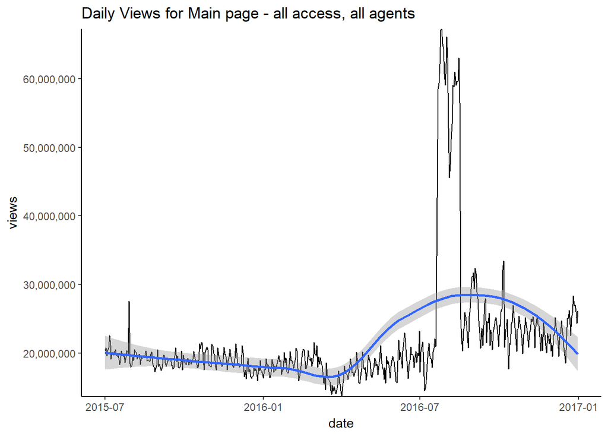

```r
plot.ts1+geom_smooth(method='loess')
```

- Increase granularity with span (between 0-1, higher is smoother)

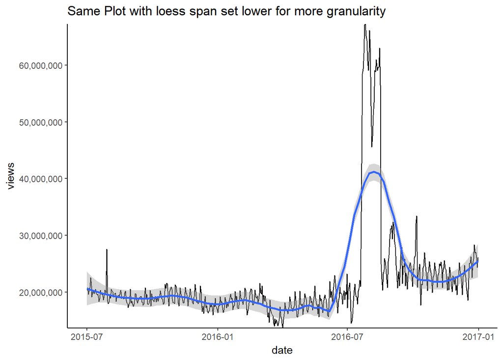

```r
plot.ts1+geom_smooth(method='loess', span=0.3)+ggtitle("Same Plot with loess span set lower for more granularity")
```

- can layer in multiple loess smoothed lines for comparison (confidence intervals removed)

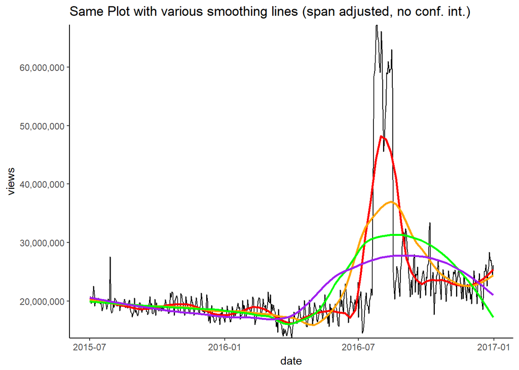

### Finding optimal smoothing span

```
## $par
## [1] -3.593712
##
## $value
## [1] 99999
##
## $counts
## function gradient
##    10000       NA
##
## $convergence
## [1] 0
##
## $message
## NULL
```

Select span value by discretion, based on eye-balling options in the chart. :)

### Approach 2

Reference: * http://r-statistics.co/Time-Series-Analysis-With-R.html

#### Convert data from data frame to time series object

- Set up time series so that can apply time series functions for decomposition, etc

```r
## time series forumlation examples from above reference line
# ts (inputData, frequency = 4, start = c(1959, 2)) # frequency 4 => Quarterly Data
# ts (1:10, frequency = 12, start = 1990) # freq 12 => Monthly data.
# ts (inputData, start=c(2009), end=c(2014), frequency=1) # Yearly Data

## See Notes below for explanation of frequency
ts.Main.all.all.wk <- ts(main.all.all.ts$views, frequency=52, start=c(year(min(main.all.all.ts$date)), month(min(main.all.all.ts$date)), day(min(main.all.all.ts$date))))
```

Notes:

- since it is daily data, time series frequency=365 (days in yr)
- however, because there is total 550 data points, not enough data for seasonality component to be estimated (need at least two iterations)
  - will get error: “time series has no or less than 2 periods”"
- so…used frequency=52 to treat the time series as weekly data for illustration purposes

More on ‘time series has no or less than 2 periods’ error:  
* https://stat.ethz.ch/pipermail/r-help/2013-October/361047.html

#### Decomposition

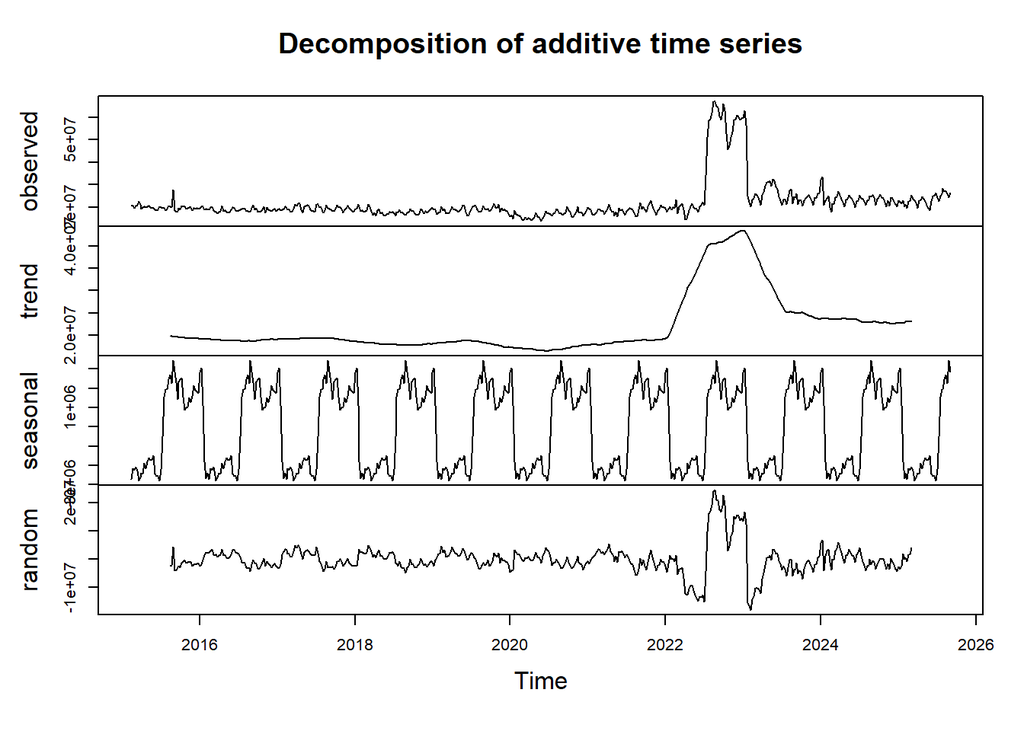